# Penyelesaian Nutrifood Transporter Routing Optimization Problem Menggunakan Spiral Dynamic Optimization Algorithm di R

Dokumentasi Hasil Trial

# PENDAHULUAN

## Latar Belakang

Setiap hari, tim DTA membuat rute untuk *transporter* mendistribusikan produk jadi ke konsumen-konsumen Nutrifood yang telah melakukan *order*. Proses ini masih dilakukan secara manual. Akibatnya proses ini memakan waktu yang cukup lama dan tidak ada kejaminan bahwa rute yang dipilih sudah optimal atau belum. Oleh karena itu, tim DTA bersama dengan tim *Digital Transformation* dan *Market Research* berusaha untuk membuat model optimisasi dari permasalahan ini.

## Tujuan

Membuat model optimisasi rute *transporter* yang meminimalkan *total cost*, yakni dengan membuat konfigurasi:

> **Order toko mana yang harus dikirim pada tanggal berapa dan menggunakan armada apa.**

## Ruang Lingkup

*Business process* yang terjadi selama ini sangat kompleks, oleh karena itu penelitian ini dibatasi pada lingkup sebagai berikut saja:

### *Business Process* yang Hendak Dikerjakan

Untuk mengirimkan produk jadi dari Gudang Ciawi dan Cibitung, tim DTA menyewa *transporter* dengan berbagai jenis armada kendaraan. Masing-masing kendaraan tersebut memiliki spesifikasi yang berbeda-beda, seperti:

1. Kapasitas maksimal kubikasi yang bisa diangkut,
2. Kapasitas maksimal tonase yang bisa diangkut,
3. Biaya sewa (per km). Diasumsikan biaya sewa ini nilainya tetap (tidak dipengaruhi oleh faktor lain seperti *habit* supir dan perbedaan rute yang ditempuh), dan
4. *Loading time*.

Masing-masing armada tersebut juga memiliki keterbatasan dari segi jumlah armada yang bisa disewa dan berapa banyak titik konsumen yang bisa dilalui.

Konsumen memesan (melalui proses *purchase order* - PO) sejumlah produk jadi kepada Nutrifood. Pada PO tersebut, kita memiliki informasi sebagai berikut:

1. Berapa total kubik dan tonase produk yang harus dikirim.
2. *Range* tanggal pengiriman produk.

Nutrifood harus memenuhi pembelian tersebut secara langsung (tidak boleh memecah pengiriman produk dalam satu PO menjadi beberapa kali pengiriman). Masing-masing konsumen akan dilayani oleh gudang Ciawi atau Cibitung sesuai dengan pembagian yang telah ditetapkan sebelumnya. Tidak ada konsumen yang dilayani oleh keduanya.

Masing-masing konsumen memiliki keterbatas lain terkait armada yang bisa dilalui karena lokasi mereka berbeda-beda. Ada konsumen yang berlokasi di jalan besar sehingga armada ukuran besar bisa melewatinya dengan aman. Namun ada beberapa konsumen yang lokasinya hanya bisa dilalui oleh armada kecil.

## Metode Penyelesaian Model Optimisasi

Untuk menyelesaikan model optimisasi ini, saya akan menggunakan pendekatan *meta heuristic* dibandingkan penyelesaian secara *exact*. Berikut alasannya:

1. Kita tidak perlu menuliskan model matematika yang kompleks karena permasalahan yang kita hadapi ini memiliki indeks yang tinggi. Kita cukup menuliskan algoritma (*computational model*) berdasarkan definisi dan *constraints* secara logis. Sehingga proses *modelling* bisa dilakukan dengan lebih cepat.
2. Penyelesaian dengan metode *exact* memang menjamin keoptimalan solusi. Sedangkan penyelesaian dengan metode *meta heuristic*, walaupun tidak ada jaminan solusi yang didapatkan adalah solusi yang paling optimal tapi kita bisa mencari solusi *near optimal* dengan melakukan *tweaking* pada algoritma tersebut.

Pendekatan *meta heuristic* yang akan saya gunakan adalah *Spiral Dynamic Optimization Algorithm*.

# *SPIRAL DYNAMIC OPTIMIZATION ALGORITHM* (SDOA)

## Penjelasan Singkat

*Spiral Dynamic Optimization Algorithm* (SDOA) adalah salah satu metode *meta heuristic* yang digunakan untuk mencari minimum global dari suatu sistem persamaan. SDOA termasuk ke dalam salah satu *greedy algorithm* yang biasa digunakan untuk memecahkan berbagai masalah dalam sains dan *engineering*.

Algoritmanya mudah dipahami dan intuitif tanpa harus memiliki latar keilmuan tertentu. Proses kerjanya adalah dengan melakukan *random number generating* pada suatu selang dan melakukan rotasi sekaligus kontraksi dengan titik paling minimum pada setiap iterasi sebagai pusatnya. Pusat rotasi akan dipilih dari calon solusi yang *near optimal*. Dengan adanya iterasi tersebut, proses eksploitasi dan eksplorasi terhadap calon solusi lain bisa dijalankan sehingga kita akan dapatkan solusi paling optimal di akhir iterasi.

Berikut adalah algoritmanya:

```
INPUT
  m >= 2 # jumlah titik
  theta  # sudut rotasi (0 <= theta <= 2pi)
  r      # konstraksi
  k_max  # iterasi maksimum
PROCESS
  1 generate m buah titik secara acak
      x_i
  2 initial condition
      k = 0 # untuk keperluan iterasi
  3 cari x_* yang memenuhi
      min(f(x_*))

  4 lakukan rotasi dan konstraksi semua x_i
      x_* sebagai pusat rotasi
      k = k + 1
  5 ulangi proses 3 dan 4
  6 hentikan proses saat k = k_max
      output x_*
```

Berdasarkan algoritma di atas, salah satu proses yang penting adalah melakukan **rotasi** dan **konstraksi** terhadap semua titik yang telah di-*generate*.

## Menyelesaikan Masalah Optimisasi dengan SDOA

Permasalahan Nutrifood terkait *transporter* merupakan salah satu bentuk *Mixed Integer Non Linear Programming* (MINLP). Secara umum, bentuk MINLP bisa ditulis sebagai berikut:

$$\min_{x \in \mathbb{R}^n} f(x)$$

$$\text{subject to: } g_i(x) = 0, i = 1,2,..,M$$

$$\text{and } h_j(x) \leq 0,i = 1,2,..,N$$

$$x = (x_1,x_2,...,x_n)^T \in \mathbb{N}$$

Agar bisa diselesaikan dengan SDOA, kita akan mengubah bentuk di atas menjadi:

$$F(x,\alpha,\beta) = f(x) + \sum_{i=1}^M \alpha_i g_i^2(x) + \sum_{j = 1}^N \beta_j (\max{(h_j(x),0)})^2$$

dimana $\alpha,\beta$ merupakan *penalty constant* yang bisa dibuat sangat besar. Model komputasi ini dikenal juga dengan sebutan *reinforce learning*.

## Matriks Rotasi untuk n-Dimensi

SOA relatif mudah untuk dituliskan dalam bentuk algoritma bahasa pemrograman manapun. Tapi ada satu hal yang bisa menjadi batu ganjalan dalam menuliskan algoritmanya. Apa itu? Yaitu pendefinisian matriks rotasi untuk masalah dengan n-dimensi.

Bentuk umum dari matriks rotasi adalah sebagai berikut:

$$R^{(n)} (\theta_{1,2},\theta_{1,3},..,\theta_{n,n-1}) = \prod_{i=1}^{n-1} \left ( \prod_{j=1}^i R^{(n)}_{n-i,n+1-j} (\theta_{n-i,n+1-j}) \right )$$

Perhatikan bahwa perkalian matriks rotasi yang dilakukan adalah *cross product* bukan *dot product* (karena rotasi tidak mengubah *norm* suatu vektor).

## Catatan Terkait Algoritma SDOA

Sampai saat ini tidak ada *library* khusus untuk SDOA karena algoritma ini bersifat umum karena sifatnya *customize* tergantung dari permasalahan yang dihadapi.

Pada kasus ini, algoritma dibuat dengan bahasa **R** dengan bantuan `library(tidyverse)` (untuk keperluan *data wrangling*) dan `library(parallel)` (untuk keperluan *parallel processing*). Oleh karena itu, algoritma ditulis dengan memanfaatkan prinsip *parallel processing*.

Algoritma ini dijalankan pada **Ubuntu OS** dengan memanfaatkan 5 *cores* *processor*.

## *Flowchart* Pengerjaan SDOA

Berikut ada *flowchart* pengerjaan dan pembuatan model ini hingga mendapatkan solusi optimal.

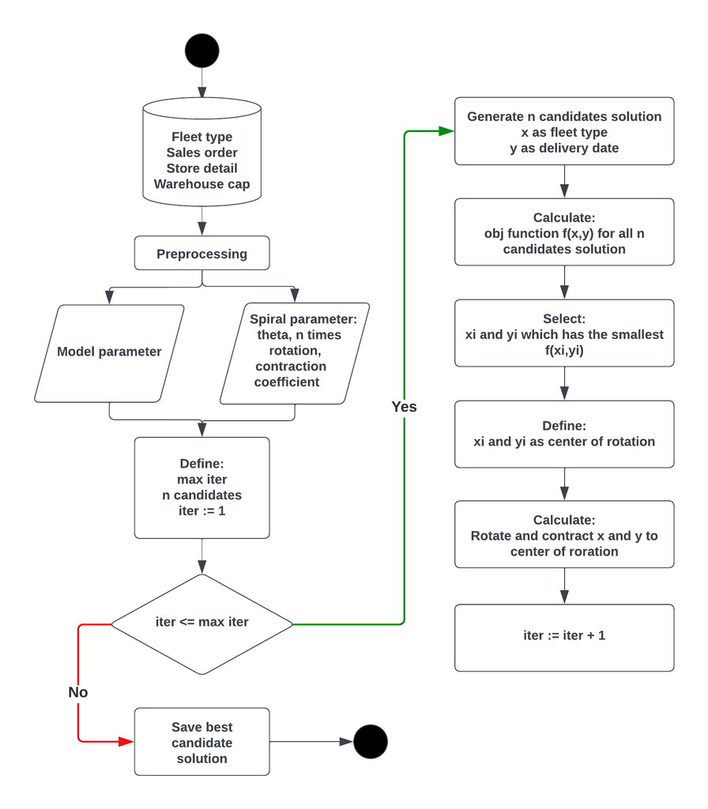

# DATA TERKAIT

Pada *report* ini, kita akan gunakan data yang sudah dihimpun oleh tim DTA dan DT. Berikut adalah data-data yang sudah dilakukan *pre-processing*:

## Data Terkait Order Toko

Untuk memudahkan perhitungan model optimisasi, saya akan memilih *sales order* pada area Bandung, Sukabumi, dan Garut. Ada `408` *sales order* yang terlibat dalam data ini:

|  | nama_toko | sales_order | order_kubikasi | order_kg | tanggal_kirim_min | tanggal_kirim_max |
| --- | --- | --- | --- | --- | --- | --- |
| 1 | HERO BANDUNG PASKAL | Ambil CN | 0.01032 | 5.23536 | 2022-11-07 | 2022-11-10 |
| 2 | MITRA PERIANGAN PERSADA - SUKABUMI, PT | 111172385 | 6.48132 | 1346.2268 | 2022-11-29 | 2022-12-05 |
| 3 | MITRA PERIANGAN PERSADA - SUKABUMI, PT | 111172386 | 0.42806 | 82.48394 | 2022-11-29 | 2022-12-05 |
| 4 | MITRA PERIANGAN PERSADA - SUKABUMI, PT | 111172387 | 2.23019568 | 642.486599568 | 2022-11-29 | 2022-12-05 |
| 5 | MITRA PERIANGAN PERSADA - SUKABUMI, PT | 111172388 | 0.0644 | 7.2356 | 2022-11-29 | 2022-12-05 |
| 6 | MITRA PERIANGAN PERSADA - SUKABUMI, PT | 111172389 | 8.65952 | 1799.4064 | 2022-11-29 | 2022-12-12 |
| 7 | MITRA PERIANGAN PERSADA - SUKABUMI, PT | 111172390 | 0.572 | 110.0576 | 2022-11-29 | 2022-12-12 |
| 8 | MITRA PERIANGAN PERSADA - SUKABUMI, PT | 111172391 | 2.72579472 | 785.261399472 | 2022-11-29 | 2022-12-12 |
| 9 | MITRA PERIANGAN PERSADA - SUKABUMI, PT | 111172392 | 0.24779952 | 71.387399952 | 2022-11-29 | 2022-12-12 |
| 10 | MITRA PERIANGAN PERSADA - SUKABUMI, PT | 111172393 | 0.10735 | 11.7832 | 2022-11-29 | 2022-12-12 |

[output cut: 398 more lines]

## Data Informasi Detail Toko

|  | nama_toko | supplied | max_armada |
| --- | --- | --- | --- |
| 1 | BSP SUKABUMI (POLOS) | ciawi | 5 |
| 2 | BSP SUKABUMI (WRP) | ciawi | 6 |
| 3 | EXERTAINMENT INDONESIA-TRANS BANDUNG, PT | ciawi | 2 |
| 4 | GRIYA ANTAPANI-P30017 | ciawi | 2 |
| 5 | GRIYA ARCAMANIK-P30018 | ciawi | 2 |
| 6 | GRIYA BATUNUNGGAL | ciawi | 2 |
| 7 | GRIYA BUAH BATU-P30020 | ciawi | 2 |
| 8 | GRIYA CINUNUK-P30047 | ciawi | 2 |
| 9 | GRIYA DINASTY-P30023 | ciawi | 2 |
| 10 | GRIYA JATINANGOR-P30046 | ciawi | 2 |

[output cut: 33 more lines]

## Data Gudang

|  | site | week_day_hour | week_end_hour |
| --- | --- | --- | --- |
| 1 | ciawi | 67.5 | 50 |
| 2 | cibitung | 81 | 60 |

Pada *trial* ini, saya hanya menggunakan data *weekday* saja.

## Data Armada

1. *Cost* per kilometer,
2. Kapasitas tonase.
3. *Max* titik customer yang bisa dikirim.
4. *Loading time*.

Terkait ketersediaan, karena ke depannya bisa berpotensi menjadi parameter yang penting maka tetap saya masukkan ke dalam model namun angkanya bisa ditetapkan suatu nilai yang “besar”.

|  | armada | jenis_armada | max_cap_kubikasi | max_cap_kg | cost_per_km | tersedia | max_titik | loading_time |
| --- | --- | --- | --- | --- | --- | --- | --- | --- |
| 1 | 1 | Carry | 5 | 1500 | 0.76 | 7 | 5 | 0.6 |
| 2 | 2 | CDE | 7 | 2000 | 1 | 7 | 5 | 0.7 |
| 3 | 3 | CDD | 12 | 5000 | 1.27 | 7 | 5 | 1.2 |
| 4 | 4 | CDD Jumbo | 17 | 5000 | 1.56 | 7 | 5 | 1.2 |
| 5 | 5 | FUSO | 24 | 9000 | 2.23 | 7 | 5 | 1.4 |
| 6 | 6 | TRONTON | 33 | 11000 | 2.56 | 7 | 5 | 1.9 |
| 7 | 7 | BU | 45 | 20000 | 3.23 | 7 | 5 | 1.9 |
| 8 | 8 | CONT 20 | 30 | 30000 | 50 | 7 | 2 | 1.9 |
| 9 | 9 | CONT 40 | 65 | 40000 | 70 | 7 | 2 | 3.4 |

# HASIL OPTIMISASI

## *Decision Variables*

Model optimisasi ini menghasilkan dua *decision variables*, yakni:

1. Tanggal kirim, dan
2. Armada yang digunakan.

Untuk masing-masing *order* toko.

## *Objective Function*

Fungsi objektif pada model ini adalah:

> Meminimumkan total biaya yang timbul dari setiap keputusan toko $i$ dikirim armada $j$ pada tanggal $k$ tanpa melanggar *constraints* yang ada.

## Solusi Model

Pengiriman tanggal: 2022-11-08

| sales_order | nama_toko | provinsi | kota_kab | kecamatan | jenis_armada | armada_ke | order_kubikasi | order_tonase |
| --- | --- | --- | --- | --- | --- | --- | --- | --- |
| Ambil CN | HERO BANDUNG PASKAL | Jawa Barat | Bandung | Andir | Carry | 1 | 0.01032 | 5.23536 |

Pengiriman tanggal: 2022-11-30

| sales_order | nama_toko | provinsi | kota_kab | kecamatan | jenis_armada | armada_ke | order_kubikasi | order_tonase |
| --- | --- | --- | --- | --- | --- | --- | --- | --- |
| 115131307 | SAT Bandung 2-P30016 | Jawa Barat | Cimahi | Cimahi Selatan | Carry | 1 | 0.6650400 | 458.334960 |
| 115131140 | YOGYA PAJAJARAN | Jawa Barat | Bandung | Cicendo | Carry | 1 | 0.0383638 | 5.707764 |
| 115131142 | YOGYA PAJAJARAN | Jawa Barat | Bandung | Cicendo | Carry | 1 | 0.0153376 | 10.869120 |

Pengiriman tanggal: 2022-12-01

| sales_order | nama_toko | provinsi | kota_kab | kecamatan | jenis_armada | armada_ke | order_kubikasi | order_tonase |
| --- | --- | --- | --- | --- | --- | --- | --- | --- |
| 115131363 | GRIYA ARCAMANIK-P30018 | Jawa Barat | Bandung | Arcamanik | Carry | 1 | 0.0519360 | 11.878929 |
| 115131364 | GRIYA ARCAMANIK-P30018 | Jawa Barat | Bandung | Arcamanik | Carry | 1 | 0.0384940 | 5.279802 |
| 115131314 | SAT Bandung 2-P30016 | Jawa Barat | Cimahi | Cimahi Selatan | Carry | 1 | 0.3081293 | 39.582336 |
| 115131317 | SAT Bandung-P30015 | Jawa Barat | Bandung | Cinambo | Carry | 1 | 0.2756794 | 59.160000 |
| 115131316 | SAT Bandung-P30015 | Jawa Barat | Bandung | Cinambo | Carry | 1 | 0.2620051 | 41.330568 |
| 115131355 | YOGYA PLAZA CIMAHI-P30049 | Jawa Barat | Cimahi | Cimahi Utara | Carry | 1 | 0.0301360 | 7.350249 |
| 111172388 | MITRA PERIANGAN PERSADA - SUKABUMI, PT | Jawa Barat | Sukabumi | Sukaraja | Fuso | 1 | 0.0644000 | 7.235600 |
| 111172389 | MITRA PERIANGAN PERSADA - SUKABUMI, PT | Jawa Barat | Sukabumi | Sukaraja | Fuso | 1 | 8.6595200 | 1799.406400 |
| 111172390 | MITRA PERIANGAN PERSADA - SUKABUMI, PT | Jawa Barat | Sukabumi | Sukaraja | Fuso | 1 | 0.5720000 | 110.057600 |
| 111172391 | MITRA PERIANGAN PERSADA - SUKABUMI, PT | Jawa Barat | Sukabumi | Sukaraja | Fuso | 1 | 2.7257947 | 785.261400 |
| 111172392 | MITRA PERIANGAN PERSADA - SUKABUMI, PT | Jawa Barat | Sukabumi | Sukaraja | Fuso | 1 | 0.2477995 | 71.387400 |
| 111172393 | MITRA PERIANGAN PERSADA - SUKABUMI, PT | Jawa Barat | Sukabumi | Sukaraja | Fuso | 1 | 0.1073500 | 11.783200 |
| 111172387 | MITRA PERIANGAN PERSADA - SUKABUMI, PT | Jawa Barat | Sukabumi | Sukaraja | Fuso | 1 | 2.2301957 | 642.486600 |
| 111172385 | MITRA PERIANGAN PERSADA - SUKABUMI, PT | Jawa Barat | Sukabumi | Sukaraja | Fuso | 1 | 6.4813200 | 1346.226800 |
| 111172386 | MITRA PERIANGAN PERSADA - SUKABUMI, PT | Jawa Barat | Sukabumi | Sukaraja | Fuso | 1 | 0.4280600 | 82.483940 |

Pengiriman tanggal: 2022-12-02

| sales_order | nama_toko | provinsi | kota_kab | kecamatan | jenis_armada | armada_ke | order_kubikasi | order_tonase |
| --- | --- | --- | --- | --- | --- | --- | --- | --- |
| 115131320 | INDOGROSIR SUKABUMI | Jawa Barat | Sukabumi | Baros | Carry | 1 | 0.0261600 | 4.454400 |
| 115131319 | INDOGROSIR SUKABUMI | Jawa Barat | Sukabumi | Baros | Carry | 1 | 0.0480661 | 7.756992 |
| 115131390 | YOGYA KOPO MAS-P30041 | Jawa Barat | Bandung | Babakan Ciparay | Carry | 1 | 0.0172550 | 5.018750 |
| 115131388 | YOGYA KOPO MAS-P30041 | Jawa Barat | Bandung | Babakan Ciparay | Carry | 1 | 0.0232163 | 4.374999 |
| 115131139 | YOGYA PAJAJARAN | Jawa Barat | Bandung | Cicendo | Carry | 1 | 0.0328774 | 7.874920 |
| 115131325 | YOGYA PAJAJARAN | Jawa Barat | Bandung | Cicendo | Carry | 1 | 0.0130800 | 2.227200 |
| 115131141 | YOGYA PAJAJARAN | Jawa Barat | Bandung | Cicendo | Carry | 1 | 0.0204600 | 5.848800 |
| 115131335 | YOGYA PAJAJARAN | Jawa Barat | Bandung | Cicendo | Carry | 1 | 0.0153600 | 10.837920 |
| 115131208 | YOGYA PAJAJARAN | Jawa Barat | Bandung | Cicendo | Carry | 1 | 0.0417600 | 6.629760 |
| 115131362 | YOMART DC GOOD STOCK | Jawa Barat | Bandung | Batununggal | Carry | 1 | 0.0192000 | 2.440080 |
| 115131360 | YOMART DC GOOD STOCK | Jawa Barat | Bandung | Batununggal | Carry | 1 | 0.0344599 | 7.152000 |

Pengiriman tanggal: 2022-12-03

| sales_order | nama_toko | provinsi | kota_kab | kecamatan | jenis_armada | armada_ke | order_kubikasi | order_tonase |
| --- | --- | --- | --- | --- | --- | --- | --- | --- |
| 115131375 | GRIYA BATUNUNGGAL | Jawa Barat | Bandung | Bandung Kidul | Carry | 1 | 0.0551700 | 6.32487 |
| 115131387 | GRIYA CINUNUK-P30047 | Jawa Barat | Bandung | Cileunyi | Carry | 1 | 0.0153600 | 10.89216 |
| 115131384 | GRIYA CINUNUK-P30047 | Jawa Barat | Bandung | Cileunyi | Carry | 1 | 0.0052250 | 2.84250 |
| 115131385 | GRIYA CINUNUK-P30047 | Jawa Barat | Bandung | Cileunyi | Carry | 1 | 0.0033900 | 0.11400 |
| 115131386 | GRIYA CINUNUK-P30047 | Jawa Barat | Bandung | Cileunyi | Carry | 1 | 0.0099801 | 2.68950 |
| 115131312 | INDOMARCO BANDUNG-P30013 | Jawa Barat | Bandung | Kiaracondong | Carry | 1 | 0.0424800 | 11.89008 |

Pengiriman tanggal: 2022-12-04

| sales_order | nama_toko | provinsi | kota_kab | kecamatan | jenis_armada | armada_ke | order_kubikasi | order_tonase |
| --- | --- | --- | --- | --- | --- | --- | --- | --- |
| 115131309 | INDOGROSIR BANDUNG-P30012 | Jawa Barat | Bandung | Kiaracondong | Carry | 1 | 0.01308 | 2.2272 |

Pengiriman tanggal: 2022-12-05

| sales_order | nama_toko | provinsi | kota_kab | kecamatan | jenis_armada | armada_ke | order_kubikasi | order_tonase |
| --- | --- | --- | --- | --- | --- | --- | --- | --- |
| 115131436 | GRIYA ANTAPANI-P30017 | Jawa Barat | Bandung | Antapani (Cicadas) | Carry | 1 | 0.0130800 | 2.227200 |
| 115131374 | GRIYA BATUNUNGGAL | Jawa Barat | Bandung | Bandung Kidul | Carry | 1 | 0.0150767 | 5.405063 |
| 115131376 | GRIYA BATUNUNGGAL | Jawa Barat | Bandung | Bandung Kidul | Carry | 1 | 0.0170400 | 8.948760 |
| 115131409 | GRIYA BATUNUNGGAL | Jawa Barat | Bandung | Bandung Kidul | Carry | 1 | 0.0153600 | 10.837920 |
| 115131373 | GRIYA BATUNUNGGAL | Jawa Barat | Bandung | Bandung Kidul | Carry | 1 | 0.0078960 | 2.855991 |
| 115131441 | GRIYA TAMAN KOPO INDAH-P30033 | Jawa Barat | Bandung | Margaasih | Carry | 1 | 0.0130800 | 2.227200 |
| 115131407 | YOGYA SUNDA-P30044 | Jawa Barat | Bandung | Sumur Bandung | Carry | 1 | 0.0153600 | 10.837920 |
| 115131412 | YOMART DC GOOD STOCK | Jawa Barat | Bandung | Batununggal | Carry | 1 | 0.0307200 | 21.792000 |
| 115131333 | YOMART DC GOOD STOCK | Jawa Barat | Bandung | Batununggal | Carry | 1 | 0.0316800 | 21.414720 |
| 115131414 | YOMART DC GOOD STOCK | Jawa Barat | Bandung | Batununggal | Carry | 1 | 0.2024527 | 54.766968 |
| 115131413 | YOMART DC GOOD STOCK | Jawa Barat | Bandung | Batununggal | Carry | 1 | 0.2507321 | 36.533866 |
| 115131359 | YOMART DC GOOD STOCK | Jawa Barat | Bandung | Batununggal | Carry | 1 | 0.0357600 | 3.859920 |
| 115131361 | YOMART DC GOOD STOCK | Jawa Barat | Bandung | Batununggal | Carry | 1 | 0.2203697 | 48.217040 |
| 115131431 | GRIYA MARGAHAYU RAYA | Jawa Barat | Bandung | Buahbatu (Margacinta) | Carry | 2 | 0.0130800 | 2.227200 |
| 115131438 | YOGYA CIHAMPELAS WALK-P30037 | Jawa Barat | Bandung | Coblong | Carry | 2 | 0.0261600 | 4.454400 |
| 115131444 | YOGYA JUNCTION SUMBER SARI | Jawa Barat | Bandung | Babakan Ciparay | Carry | 2 | 0.0130800 | 2.227200 |
| 115131337 | YOGYA KEPATIHAN-P30040 | Jawa Barat | Bandung | Regol | Carry | 2 | 0.0153600 | 10.837920 |
| 115131326 | YOGYA KEPATIHAN-P30040 | Jawa Barat | Bandung | Regol | Carry | 2 | 0.0130800 | 2.227200 |
| 115131433 | YOGYA KEPATIHAN-P30040 | Jawa Barat | Bandung | Regol | Carry | 2 | 0.0734393 | 16.550409 |
| 115131416 | YOGYA KEPATIHAN-P30040 | Jawa Barat | Bandung | Regol | Carry | 2 | 0.0307200 | 21.781440 |
| 115131426 | GRIYA BUAH BATU-P30020 | Jawa Barat | Bandung | Lengkong | Carry | 3 | 0.0130800 | 2.227200 |
| 115131410 | GRIYA BUAH BATU-P30020 | Jawa Barat | Bandung | Lengkong | Carry | 3 | 0.0153600 | 10.837920 |
| 115131382 | GRIYA CINUNUK-P30047 | Jawa Barat | Bandung | Cileunyi | Carry | 3 | 0.1092720 | 25.962990 |
| 115131344 | GRIYA CINUNUK-P30047 | Jawa Barat | Bandung | Cileunyi | Carry | 3 | 0.0153600 | 10.837920 |
| 115131383 | GRIYA CINUNUK-P30047 | Jawa Barat | Bandung | Cileunyi | Carry | 3 | 0.0690869 | 9.938184 |
| 115131437 | GRIYA CINUNUK-P30047 | Jawa Barat | Bandung | Cileunyi | Carry | 3 | 0.0130800 | 2.227200 |
| 115131308 | INDOGROSIR BANDUNG-P30012 | Jawa Barat | Bandung | Kiaracondong | Carry | 3 | 0.3370454 | 94.549500 |
| 115131396 | INDOGROSIR BANDUNG-P30012 | Jawa Barat | Bandung | Kiaracondong | Carry | 3 | 0.0523200 | 8.908800 |
| 115131395 | INDOGROSIR BANDUNG-P30012 | Jawa Barat | Bandung | Kiaracondong | Carry | 3 | 0.3602196 | 97.399600 |
| 115131358 | YOGYA PLAZA CIMAHI-P30049 | Jawa Barat | Cimahi | Cimahi Utara | Carry | 3 | 0.0076800 | 5.446080 |
| 115131372 | YOGYA PLAZA CIMAHI-P30049 | Jawa Barat | Cimahi | Cimahi Utara | Carry | 3 | 0.1332000 | 92.367840 |
| 115131443 | YOGYA PLAZA CIMAHI-P30049 | Jawa Barat | Cimahi | Cimahi Utara | Carry | 3 | 0.0261600 | 4.454400 |
| 115131354 | YOGYA PLAZA CIMAHI-P30049 | Jawa Barat | Cimahi | Cimahi Utara | Carry | 3 | 0.0104500 | 5.685000 |
| 115131356 | YOGYA PLAZA CIMAHI-P30049 | Jawa Barat | Cimahi | Cimahi Utara | Carry | 3 | 0.0663936 | 10.239282 |
| 115131371 | YOGYA PLAZA CIMAHI-P30049 | Jawa Barat | Cimahi | Cimahi Utara | Carry | 3 | 0.0129900 | 1.454970 |
| 115131370 | YOGYA PLAZA CIMAHI-P30049 | Jawa Barat | Cimahi | Cimahi Utara | Carry | 3 | 0.0208922 | 5.508578 |
| 115131357 | YOGYA PLAZA CIMAHI-P30049 | Jawa Barat | Cimahi | Cimahi Utara | Carry | 3 | 0.0252670 | 6.989128 |
| 115131365 | YOGYA PLAZA CIMAHI-P30049 | Jawa Barat | Cimahi | Cimahi Utara | Carry | 3 | 0.0805739 | 17.772339 |
| 115131366 | YOGYA PLAZA CIMAHI-P30049 | Jawa Barat | Cimahi | Cimahi Utara | Carry | 3 | 0.0078540 | 4.000014 |
| 115131369 | YOGYA PLAZA CIMAHI-P30049 | Jawa Barat | Cimahi | Cimahi Utara | Carry | 3 | 0.0067800 | 0.228000 |
| 115131367 | YOGYA PLAZA CIMAHI-P30049 | Jawa Barat | Cimahi | Cimahi Utara | Carry | 3 | 0.0188750 | 2.333598 |
| 115131368 | YOGYA PLAZA CIMAHI-P30049 | Jawa Barat | Cimahi | Cimahi Utara | Carry | 3 | 0.0288335 | 18.897990 |
| 115131332 | YOMART GEDEBAGE | Jawa Barat | Bandung | Arcamanik | Carry | 3 | 0.0490600 | 14.576000 |
| 115131415 | YOMART GEDEBAGE | Jawa Barat | Bandung | Arcamanik | Carry | 3 | 0.0178800 | 1.929960 |
| 115131411 | YOMART GEDEBAGE | Jawa Barat | Bandung | Arcamanik | Carry | 3 | 0.1366690 | 18.238200 |
| 115131439 | GRIYA SETIABUDI-P30030 | DKI Jakarta | Jakarta Selatan | Setia Budi | Carry | 4 | 0.0130800 | 2.227200 |
| 115131310 | INDOMARCO WH KLIK I-PLAZA BANDUNG | Jawa Barat | Bandung | Cibeunying Kidul | Carry | 4 | 0.0593296 | 12.571980 |
| 115131311 | INDOMARCO WH KLIK I-PLAZA BANDUNG | Jawa Barat | Bandung | Cibeunying Kidul | Carry | 4 | 0.0209000 | 11.370000 |
| 115131405 | YOGYA DC - BUAH BATU | Jawa Barat | Bandung | Bandung Kidul | Carry | 4 | 0.0784800 | 13.363200 |
| 115131417 | YOGYA DC - BUAH BATU | Jawa Barat | Bandung | Bandung Kidul | Carry | 4 | 0.1066897 | 18.819978 |
| 115131418 | YOGYA DC - BUAH BATU | Jawa Barat | Bandung | Bandung Kidul | Carry | 4 | 0.0921600 | 65.027520 |
| 115131430 | YOGYA KOPO MAS-P30041 | Jawa Barat | Bandung | Babakan Ciparay | Carry | 4 | 0.0130800 | 2.227200 |
| 115131423 | GRIYA PASTEUR-P30028 | Jawa Barat | Bandung | Cicendo | Carry | 5 | 0.0171935 | 11.034000 |
| 115131421 | GRIYA PASTEUR-P30028 | Jawa Barat | Bandung | Cicendo | Carry | 5 | 0.0568234 | 12.550340 |
| 115131422 | GRIYA PASTEUR-P30028 | Jawa Barat | Bandung | Cicendo | Carry | 5 | 0.0049020 | 2.386122 |
| 115131425 | GRIYA PASTEUR-P30028 | Jawa Barat | Bandung | Cicendo | Carry | 5 | 0.0324000 | 3.919920 |
| 115131424 | GRIYA PASTEUR-P30028 | Jawa Barat | Bandung | Cicendo | Carry | 5 | 0.0277711 | 7.748984 |
| 115131435 | GRIYA PASTEUR-P30028 | Jawa Barat | Bandung | Cicendo | Carry | 5 | 0.0130800 | 2.227200 |
| 115131429 | GRIYA SETRASARI-P30031 | Jawa Barat | Bandung | Sukajadi | Carry | 5 | 0.0130800 | 2.227200 |
| 115131408 | YOGYA JUNCTION 8 | Jawa Barat | Bandung | Sukajadi | Carry | 5 | 0.0153600 | 10.837920 |
| 115131427 | YOGYA PAJAJARAN | Jawa Barat | Bandung | Cicendo | Carry | 5 | 0.0261600 | 4.454400 |
| 115131442 | GRIYA JATINANGOR-P30046 | Jawa Barat | Sumedang | Cisitu | Carry | 6 | 0.0130800 | 2.227200 |
| 115131406 | GRIYA JATINANGOR-P30046 | Jawa Barat | Sumedang | Cisitu | Carry | 6 | 0.0182856 | 5.606992 |
| 115131440 | GRIYA PAHLAWAN-P30027 | Jawa Barat | Bandung | Cibeunying Kaler | Carry | 6 | 0.0130800 | 2.227200 |
| 115131434 | GRIYA UJUNG BERUNG-P30034 | Jawa Barat | Majalengka | Sindangwangi | Carry | 6 | 0.0889861 | 14.754753 |
| 115131432 | GRIYA UJUNG BERUNG-P30034 | Jawa Barat | Majalengka | Sindangwangi | Carry | 6 | 0.0130800 | 2.227200 |
| 115131419 | YOGYA CIUMBULEUIT | Jawa Barat | Bandung | Cidadap | Carry | 6 | 0.0107450 | 5.672490 |
| 115131420 | YOGYA CIUMBULEUIT | Jawa Barat | Bandung | Cidadap | Carry | 6 | 0.0024700 | 0.401670 |
| 115131404 | YOGYA CIUMBULEUIT | Jawa Barat | Bandung | Cidadap | Carry | 6 | 0.0153600 | 10.837920 |
| 115131378 | YOGYA MEKAR WANGI | Jawa Barat | Bandung | Bojongloa Kidul | Carry | 6 | 0.1138978 | 20.097936 |
| 115131377 | YOGYA MEKAR WANGI | Jawa Barat | Bandung | Bojongloa Kidul | Carry | 6 | 0.0889919 | 19.580916 |
| NA | YOGYA MEKAR WANGI | Jawa Barat | Bandung | Bojongloa Kidul | Carry | 6 | 0.0228000 | 2.485500 |
| 115131428 | YOGYA MEKAR WANGI | Jawa Barat | Bandung | Bojongloa Kidul | Carry | 6 | 0.0130800 | 2.227200 |
| 115131381 | YOGYA MEKAR WANGI | Jawa Barat | Bandung | Bojongloa Kidul | Carry | 6 | 0.0206400 | 10.470720 |
| 115131379 | YOGYA MEKAR WANGI | Jawa Barat | Bandung | Bojongloa Kidul | Carry | 6 | 0.0334500 | 8.940000 |

Pengiriman tanggal: 2022-12-06

| sales_order | nama_toko | provinsi | kota_kab | kecamatan | jenis_armada | armada_ke | order_kubikasi | order_tonase |
| --- | --- | --- | --- | --- | --- | --- | --- | --- |
| 111172679 | BSP SUKABUMI (WRP) | Jawa Barat | Sukabumi | Sukaraja | Carry | 1 | 0.1838400 | 41.548600 |
| 115131448 | GRIYA TAMAN KOPO INDAH-P30033 | Jawa Barat | Bandung | Margaasih | Carry | 1 | 0.0024700 | 0.401670 |
| 115131456 | INDOGROSIR SUKABUMI | Jawa Barat | Sukabumi | Baros | Carry | 1 | 0.0931775 | 20.700000 |
| 115131457 | INDOGROSIR SUKABUMI | Jawa Barat | Sukabumi | Baros | Carry | 1 | 0.0654000 | 11.136000 |
| 115131458 | SAT Bandung 2-P30016 | Jawa Barat | Cimahi | Cimahi Selatan | Carry | 1 | 0.4967395 | 72.956436 |
| 115131460 | SAT Bandung 2-P30016 | Jawa Barat | Cimahi | Cimahi Selatan | Carry | 1 | 0.1722696 | 37.358000 |
| 115131445 | YOGYA SUNDA-P30044 | Jawa Barat | Bandung | Sumur Bandung | Carry | 1 | 0.0130800 | 2.227200 |
| 115131394 | INDOMARCO WH KLIK I-PLAZA BANDUNG | Jawa Barat | Bandung | Cibeunying Kidul | Carry | 2 | 0.0324000 | 3.919920 |
| 115131453 | INDOMARCO WH KLIK I-PLAZA BANDUNG | Jawa Barat | Bandung | Cibeunying Kidul | Carry | 2 | 0.0263440 | 5.899998 |
| 115131398 | INDOMARCO WH KLIK I-PLAZA BANDUNG | Jawa Barat | Bandung | Cibeunying Kidul | Carry | 2 | 0.1256640 | 29.425044 |
| 115131400 | INDOMARCO WH KLIK I-PLAZA BANDUNG | Jawa Barat | Bandung | Cibeunying Kidul | Carry | 2 | 0.1993661 | 76.926854 |
| 115131399 | INDOMARCO WH KLIK I-PLAZA BANDUNG | Jawa Barat | Bandung | Cibeunying Kidul | Carry | 2 | 0.1119736 | 24.371778 |
| 115131524 | SAT Bandung-P30015 | Jawa Barat | Bandung | Cinambo | Carry | 2 | 0.0076800 | 5.418960 |
| 115131461 | SAT Bandung-P30015 | Jawa Barat | Bandung | Cinambo | Carry | 2 | 0.9898915 | 156.080400 |
| 115131523 | SAT Bandung-P30015 | Jawa Barat | Bandung | Cinambo | Carry | 2 | 0.0619200 | 31.412160 |
| 115131459 | SAT Bandung-P30015 | Jawa Barat | Bandung | Cinambo | Carry | 2 | 0.5059594 | 223.217600 |
| 115131446 | YOGYA DC - BUAH BATU | Jawa Barat | Bandung | Bandung Kidul | Carry | 2 | 0.0784800 | 13.363200 |
| 115131508 | YOGYA PAJAJARAN | Jawa Barat | Bandung | Cicendo | Carry | 2 | 0.0608912 | 10.145711 |
| 115131447 | YOGYA PAJAJARAN | Jawa Barat | Bandung | Cicendo | Carry | 2 | 0.0089400 | 0.964980 |
| 115131509 | YOGYA PAJAJARAN | Jawa Barat | Bandung | Cicendo | Carry | 2 | 0.0496242 | 14.244656 |
| 115131510 | YOGYA PAJAJARAN | Jawa Barat | Bandung | Cicendo | Carry | 2 | 0.0321376 | 21.611640 |
| 115131507 | YOGYA PAJAJARAN | Jawa Barat | Bandung | Cicendo | Carry | 2 | 0.0483055 | 10.792589 |
| 115131499 | YOGYA RIAU-P30043 | Jawa Barat | Bandung | Bandung Wetan | Carry | 2 | 0.0669600 | 37.076640 |
| 115131498 | YOGYA RIAU-P30043 | Jawa Barat | Bandung | Bandung Wetan | Carry | 2 | 0.0304000 | 3.314000 |
| 115131450 | YOGYA RIAU-P30043 | Jawa Barat | Bandung | Bandung Wetan | Carry | 2 | 0.2300530 | 53.579251 |
| 115131452 | YOGYA RIAU-P30043 | Jawa Barat | Bandung | Bandung Wetan | Carry | 2 | 0.3221161 | 67.236582 |
| 115131496 | YOGYA RIAU-P30043 | Jawa Barat | Bandung | Bandung Wetan | Carry | 2 | 0.0465542 | 13.094496 |
| 115131493 | YOGYA RIAU-P30043 | Jawa Barat | Bandung | Bandung Wetan | Carry | 2 | 0.0255600 | 6.378480 |
| 115131494 | YOGYA RIAU-P30043 | Jawa Barat | Bandung | Bandung Wetan | Carry | 2 | 0.0651270 | 34.689960 |
| 115131474 | YOGYA RIAU-P30043 | Jawa Barat | Bandung | Bandung Wetan | Carry | 2 | 0.0187200 | 2.290080 |
| 115131497 | YOGYA RIAU-P30043 | Jawa Barat | Bandung | Bandung Wetan | Carry | 2 | 0.0698400 | 7.749840 |
| 115131495 | YOGYA RIAU-P30043 | Jawa Barat | Bandung | Bandung Wetan | Carry | 2 | 0.0247000 | 4.016700 |

Pengiriman tanggal: 2022-12-07

| sales_order | nama_toko | provinsi | kota_kab | kecamatan | jenis_armada | armada_ke | order_kubikasi | order_tonase |
| --- | --- | --- | --- | --- | --- | --- | --- | --- |
| 115131581 | HYFRESH BIP BANDUNG | Jawa Barat | Bandung | Cibeunying Kidul | Carry | 1 | 0.0141950 | 6.24611 |
| 115131585 | HYPERMART METRO TC BANDUNG-P30011 | Jawa Barat | Bandung | Buahbatu (Margacinta) | Carry | 1 | 0.0730470 | 13.40999 |
| 115131455 | INDOMARCO BANDUNG-P30013 | Jawa Barat | Bandung | Kiaracondong | Carry | 1 | 0.0849600 | 23.78016 |
| 115131401 | INDOMARCO BANDUNG-P30013 | Jawa Barat | Bandung | Kiaracondong | Carry | 1 | 0.0849600 | 23.78016 |
| 115131397 | INDOMARCO BANDUNG-P30013 | Jawa Barat | Bandung | Kiaracondong | Carry | 1 | 0.4648800 | 50.17896 |
| 115131580 | YOGYA DC - BUAH BATU | Jawa Barat | Bandung | Bandung Kidul | Carry | 1 | 0.4122763 | 88.68438 |
| 115131576 | YOGYA DC - BUAH BATU | Jawa Barat | Bandung | Bandung Kidul | Carry | 1 | 0.5809710 | 93.98310 |
| 115131587 | YOGYA DC - BUAH BATU | Jawa Barat | Bandung | Bandung Kidul | Carry | 1 | 0.0481398 | 6.10002 |
| 115131579 | YOGYA DC - BUAH BATU | Jawa Barat | Bandung | Bandung Kidul | Carry | 1 | 0.0668398 | 34.65498 |
| 115131577 | YOGYA DC - BUAH BATU | Jawa Barat | Bandung | Bandung Kidul | Carry | 1 | 0.1175000 | 23.74640 |
| 115131578 | YOGYA DC - BUAH BATU | Jawa Barat | Bandung | Bandung Kidul | Carry | 1 | 0.2065989 | 59.31259 |
| 115131597 | EXERTAINMENT INDONESIA-TRANS BANDUNG, PT | Jawa Barat | Bandung | Batununggal | Carry | 2 | 0.0158400 | 10.70736 |
| 115131540 | GRIYA BUAH BATU-P30020 | Jawa Barat | Bandung | Lengkong | Carry | 2 | 0.2338104 | 66.68083 |
| 115131593 | SAT Bandung 2-P30016 | Jawa Barat | Cimahi | Cimahi Selatan | Carry | 2 | 0.0309600 | 15.70608 |
| 115131594 | SAT Bandung 2-P30016 | Jawa Barat | Cimahi | Cimahi Selatan | Carry | 2 | 0.0076800 | 5.41896 |
| 111172725 | BSP SUKABUMI (POLOS) | Jawa Barat | Sukabumi | Sukaraja | CDE | 1 | 1.8437200 | 451.67200 |
| 111172726 | BSP SUKABUMI (POLOS) | Jawa Barat | Sukabumi | Sukaraja | CDE | 1 | 1.4471037 | 409.50000 |
| 111172727 | BSP SUKABUMI (POLOS) | Jawa Barat | Sukabumi | Sukaraja | CDE | 1 | 2.2978800 | 530.41830 |

Pengiriman tanggal: 2022-12-08

| sales_order | nama_toko | provinsi | kota_kab | kecamatan | jenis_armada | armada_ke | order_kubikasi | order_tonase |
| --- | --- | --- | --- | --- | --- | --- | --- | --- |
| 115131649 | GRIYA BATUNUNGGAL | Jawa Barat | Bandung | Bandung Kidul | Carry | 1 | 0.0268576 | 19.062200 |
| 115131648 | GRIYA BATUNUNGGAL | Jawa Barat | Bandung | Bandung Kidul | Carry | 1 | 0.0324000 | 3.717450 |
| 115131511 | GRIYA BATUNUNGGAL | Jawa Barat | Bandung | Bandung Kidul | Carry | 1 | 0.0386120 | 9.012793 |
| 115131647 | GRIYA BATUNUNGGAL | Jawa Barat | Bandung | Bandung Kidul | Carry | 1 | 0.0240260 | 7.018299 |
| 115131512 | GRIYA BATUNUNGGAL | Jawa Barat | Bandung | Bandung Kidul | Carry | 1 | 0.0814765 | 13.330415 |
| 115131645 | GRIYA BATUNUNGGAL | Jawa Barat | Bandung | Bandung Kidul | Carry | 1 | 0.0036960 | 1.241751 |
| 115131323 | GRIYA BATUNUNGGAL | Jawa Barat | Bandung | Bandung Kidul | Carry | 1 | 0.0130800 | 2.227200 |
| 115131520 | GRIYA DINASTY-P30023 | Jawa Barat | Bandung | Batununggal | Carry | 1 | 0.0410232 | 9.536520 |
| 115131667 | GRIYA DINASTY-P30023 | Jawa Barat | Bandung | Batununggal | Carry | 1 | 0.1152000 | 81.686400 |
| 115131339 | GRIYA DINASTY-P30023 | Jawa Barat | Bandung | Batununggal | Carry | 1 | 0.0153600 | 10.837920 |
| 115131522 | GRIYA DINASTY-P30023 | Jawa Barat | Bandung | Batununggal | Carry | 1 | 0.0038400 | 2.724960 |
| 115131636 | GRIYA DINASTY-P30023 | Jawa Barat | Bandung | Batununggal | Carry | 1 | 0.0384000 | 27.230400 |
| 115131521 | GRIYA DINASTY-P30023 | Jawa Barat | Bandung | Batununggal | Carry | 1 | 0.0504211 | 7.970922 |
| 115131619 | SAT Bandung 2-P30016 | Jawa Barat | Cimahi | Cimahi Selatan | Carry | 1 | 0.0688898 | 13.958000 |
| 115131618 | SAT Bandung 2-P30016 | Jawa Barat | Cimahi | Cimahi Selatan | Carry | 1 | 0.2500248 | 39.903252 |
| 115131621 | SAT Bandung-P30015 | Jawa Barat | Bandung | Cinambo | Carry | 1 | 0.4660793 | 173.656000 |
| 115131620 | SAT Bandung-P30015 | Jawa Barat | Bandung | Cinambo | Carry | 1 | 0.1386605 | 21.330600 |
| 115131668 | SAT Bandung-P30015 | Jawa Barat | Bandung | Cinambo | Carry | 1 | 0.0206400 | 10.470720 |
| 115131635 | YOMART DC GOOD STOCK | Jawa Barat | Bandung | Batununggal | Carry | 1 | 0.0172000 | 3.012000 |
| 115131465 | YOMART DC GOOD STOCK | Jawa Barat | Bandung | Batununggal | Carry | 1 | 0.1331551 | 92.380320 |
| 115131470 | YOMART DC GOOD STOCK | Jawa Barat | Bandung | Batununggal | Carry | 1 | 0.0536400 | 5.789880 |
| 115131467 | YOMART DC GOOD STOCK | Jawa Barat | Bandung | Batununggal | Carry | 1 | 0.3287002 | 49.191082 |
| 115131631 | YOMART DC GOOD STOCK | Jawa Barat | Bandung | Batununggal | Carry | 1 | 0.0946102 | 26.360500 |
| 115131468 | YOMART DC GOOD STOCK | Jawa Barat | Bandung | Batununggal | Carry | 1 | 0.0096000 | 1.220040 |
| 115131464 | YOMART DC GOOD STOCK | Jawa Barat | Bandung | Batununggal | Carry | 1 | 0.0076800 | 5.418960 |
| 115131638 | YOGYA PLAZA CIMAHI-P30049 | Jawa Barat | Cimahi | Cimahi Utara | Carry | 2 | 0.0571255 | 13.541070 |
| 115131625 | YOGYA PLAZA CIMAHI-P30049 | Jawa Barat | Cimahi | Cimahi Utara | Carry | 2 | 0.0173067 | 4.649333 |
| 115131644 | YOGYA PLAZA CIMAHI-P30049 | Jawa Barat | Cimahi | Cimahi Utara | Carry | 2 | 0.0180000 | 10.685280 |
| 115131623 | YOGYA PLAZA CIMAHI-P30049 | Jawa Barat | Cimahi | Cimahi Utara | Carry | 2 | 0.0160800 | 3.403680 |
| 115131642 | YOGYA PLAZA CIMAHI-P30049 | Jawa Barat | Cimahi | Cimahi Utara | Carry | 2 | 0.0397733 | 10.745562 |

Pengiriman tanggal: 2022-12-09

| sales_order | nama_toko | provinsi | kota_kab | kecamatan | jenis_armada | armada_ke | order_kubikasi | order_tonase |
| --- | --- | --- | --- | --- | --- | --- | --- | --- |
| 111172778 | MITRA PERIANGAN PERSADA - SUKABUMI, PT | Jawa Barat | Sukabumi | Sukaraja | Carry | 1 | 1.4624000 | 263.356000 |
| 115131502 | YOGYA JUNCTION SUMBER SARI | Jawa Barat | Bandung | Babakan Ciparay | Carry | 1 | 0.0153151 | 10.892080 |
| 115131483 | YOGYA JUNCTION SUMBER SARI | Jawa Barat | Bandung | Babakan Ciparay | Carry | 1 | 0.1785790 | 31.999641 |
| 115131501 | YOGYA JUNCTION SUMBER SARI | Jawa Barat | Bandung | Babakan Ciparay | Carry | 1 | 0.0229866 | 11.812500 |
| 115131479 | YOGYA JUNCTION SUMBER SARI | Jawa Barat | Bandung | Babakan Ciparay | Carry | 1 | 0.0304000 | 3.314000 |
| 115131486 | YOGYA JUNCTION SUMBER SARI | Jawa Barat | Bandung | Babakan Ciparay | Carry | 1 | 0.0229951 | 16.296000 |
| 115131500 | YOGYA JUNCTION SUMBER SARI | Jawa Barat | Bandung | Babakan Ciparay | Carry | 1 | 0.0044280 | 2.456253 |
| 115131482 | YOGYA JUNCTION SUMBER SARI | Jawa Barat | Bandung | Babakan Ciparay | Carry | 1 | 0.0435280 | 9.795000 |
| 115131484 | YOGYA JUNCTION SUMBER SARI | Jawa Barat | Bandung | Babakan Ciparay | Carry | 1 | 0.1002676 | 28.066870 |
| 115131480 | YOGYA JUNCTION SUMBER SARI | Jawa Barat | Bandung | Babakan Ciparay | Carry | 1 | 0.0046800 | 0.572520 |
| 115131353 | YOGYA JUNCTION SUMBER SARI | Jawa Barat | Bandung | Babakan Ciparay | Carry | 1 | 0.0153600 | 10.837920 |
| 115131485 | YOGYA JUNCTION SUMBER SARI | Jawa Barat | Bandung | Babakan Ciparay | Carry | 1 | 0.0648000 | 7.434900 |
| 115131490 | YOGYA KEPATIHAN-P30040 | Jawa Barat | Bandung | Regol | Carry | 1 | 0.0567385 | 12.745839 |
| 115131679 | YOGYA KEPATIHAN-P30040 | Jawa Barat | Bandung | Regol | Carry | 1 | 0.0249600 | 2.753640 |
| 115131492 | YOGYA KEPATIHAN-P30040 | Jawa Barat | Bandung | Regol | Carry | 1 | 0.0178800 | 1.929960 |
| 115131491 | YOGYA KEPATIHAN-P30040 | Jawa Barat | Bandung | Regol | Carry | 1 | 0.0179429 | 2.630022 |
| 115131514 | YOGYA KOPO MAS-P30041 | Jawa Barat | Bandung | Babakan Ciparay | Carry | 1 | 0.0073260 | 3.292671 |
| 115131516 | YOGYA KOPO MAS-P30041 | Jawa Barat | Bandung | Babakan Ciparay | Carry | 1 | 0.0182000 | 5.260800 |
| 115131340 | YOGYA KOPO MAS-P30041 | Jawa Barat | Bandung | Babakan Ciparay | Carry | 1 | 0.0153600 | 10.837920 |
| 115131518 | YOGYA KOPO MAS-P30041 | Jawa Barat | Bandung | Babakan Ciparay | Carry | 1 | 0.0076000 | 0.828500 |
| 115131515 | YOGYA KOPO MAS-P30041 | Jawa Barat | Bandung | Babakan Ciparay | Carry | 1 | 0.0303670 | 4.214031 |
| 115131519 | YOGYA KOPO MAS-P30041 | Jawa Barat | Bandung | Babakan Ciparay | Carry | 1 | 0.0153151 | 10.871000 |
| 115131513 | YOGYA KOPO MAS-P30041 | Jawa Barat | Bandung | Babakan Ciparay | Carry | 1 | 0.0576686 | 13.140517 |
| 115131517 | YOGYA KOPO MAS-P30041 | Jawa Barat | Bandung | Babakan Ciparay | Carry | 1 | 0.0189900 | 2.269980 |
| 115131601 | GRIYA ARCAMANIK-P30018 | Jawa Barat | Bandung | Arcamanik | Carry | 2 | 0.0461809 | 12.568289 |
| 115131599 | GRIYA ARCAMANIK-P30018 | Jawa Barat | Bandung | Arcamanik | Carry | 2 | 0.0738545 | 11.103561 |
| 115131598 | GRIYA ARCAMANIK-P30018 | Jawa Barat | Bandung | Arcamanik | Carry | 2 | 0.0272610 | 6.081000 |
| 115131602 | GRIYA ARCAMANIK-P30018 | Jawa Barat | Bandung | Arcamanik | Carry | 2 | 0.2560800 | 179.508000 |
| 115131345 | GRIYA ARCAMANIK-P30018 | Jawa Barat | Bandung | Arcamanik | Carry | 2 | 0.0076800 | 5.418960 |
| 115131600 | GRIYA ARCAMANIK-P30018 | Jawa Barat | Bandung | Arcamanik | Carry | 2 | 0.0035817 | 1.890830 |

[output cut: 64 more lines]

Pengiriman tanggal: 2022-12-10

| sales_order | nama_toko | provinsi | kota_kab | kecamatan | jenis_armada | armada_ke | order_kubikasi | order_tonase |
| --- | --- | --- | --- | --- | --- | --- | --- | --- |
| 115131570 | GRIYA MARGAHAYU RAYA | Jawa Barat | Bandung | Buahbatu (Margacinta) | Carry | 1 | 0.0014760 | 0.818751 |
| 115131571 | GRIYA MARGAHAYU RAYA | Jawa Barat | Bandung | Buahbatu (Margacinta) | Carry | 1 | 0.0725435 | 11.200314 |
| 115131573 | GRIYA MARGAHAYU RAYA | Jawa Barat | Bandung | Buahbatu (Margacinta) | Carry | 1 | 0.0198321 | 5.491078 |
| 115131569 | GRIYA MARGAHAYU RAYA | Jawa Barat | Bandung | Buahbatu (Margacinta) | Carry | 1 | 0.0654332 | 14.977855 |
| 115131343 | GRIYA MARGAHAYU RAYA | Jawa Barat | Bandung | Buahbatu (Margacinta) | Carry | 1 | 0.0153600 | 10.837920 |
| 115131574 | GRIYA MARGAHAYU RAYA | Jawa Barat | Bandung | Buahbatu (Margacinta) | Carry | 1 | 0.0174600 | 1.937460 |
| 115131572 | GRIYA MARGAHAYU RAYA | Jawa Barat | Bandung | Buahbatu (Margacinta) | Carry | 1 | 0.0107618 | 5.842500 |
| 115131575 | GRIYA MARGAHAYU RAYA | Jawa Barat | Bandung | Buahbatu (Margacinta) | Carry | 1 | 0.0116400 | 8.122920 |
| 115131666 | GRIYA MARGAHAYU RAYA | Jawa Barat | Bandung | Buahbatu (Margacinta) | Carry | 1 | 0.0360270 | 10.252328 |
| 115131665 | GRIYA PAHLAWAN-P30027 | Jawa Barat | Bandung | Cibeunying Kaler | Carry | 1 | 0.0081000 | 0.979980 |
| 115131698 | GRIYA PAHLAWAN-P30027 | Jawa Barat | Bandung | Cibeunying Kaler | Carry | 1 | 0.1539155 | 0.000000 |
| 115131664 | GRIYA PAHLAWAN-P30027 | Jawa Barat | Bandung | Cibeunying Kaler | Carry | 1 | 0.0049400 | 0.803340 |
| 115131663 | GRIYA PAHLAWAN-P30027 | Jawa Barat | Bandung | Cibeunying Kaler | Carry | 1 | 0.0055367 | 3.000000 |
| 115131661 | GRIYA PAHLAWAN-P30027 | Jawa Barat | Bandung | Cibeunying Kaler | Carry | 1 | 0.1423216 | 34.501488 |
| 115131662 | GRIYA PAHLAWAN-P30027 | Jawa Barat | Bandung | Cibeunying Kaler | Carry | 1 | 0.0029520 | 1.637502 |
| 115131349 | GRIYA PAHLAWAN-P30027 | Jawa Barat | Bandung | Cibeunying Kaler | Carry | 1 | 0.0153600 | 10.837920 |
| 115131702 | GRIYA PAHLAWAN-P30027 | Jawa Barat | Bandung | Cibeunying Kaler | Carry | 1 | 0.0164066 | 0.000000 |
| 115131703 | GRIYA PAHLAWAN-P30027 | Jawa Barat | Bandung | Cibeunying Kaler | Carry | 1 | 0.0627699 | 0.000000 |
| 115131701 | GRIYA PAHLAWAN-P30027 | Jawa Barat | Bandung | Cibeunying Kaler | Carry | 1 | 0.0251400 | 0.000000 |
| 115131699 | GRIYA PAHLAWAN-P30027 | Jawa Barat | Bandung | Cibeunying Kaler | Carry | 1 | 0.1084108 | 0.000000 |
| 115131481 | GRIYA PAHLAWAN-P30027 | Jawa Barat | Bandung | Cibeunying Kaler | Carry | 1 | 0.0537600 | 38.122560 |
| 115131705 | HERO BANDUNG PASKAL | Jawa Barat | Bandung | Andir | Carry | 1 | 0.0096000 | 1.220040 |
| 115131568 | YOGYA CIUMBULEUIT | Jawa Barat | Bandung | Cidadap | Carry | 1 | 0.0398176 | 27.056760 |
| 115131328 | YOGYA CIUMBULEUIT | Jawa Barat | Bandung | Cidadap | Carry | 1 | 0.0130800 | 2.227200 |
| 115131564 | YOGYA CIUMBULEUIT | Jawa Barat | Bandung | Cidadap | Carry | 1 | 0.0372762 | 7.859088 |
| 115131567 | YOGYA CIUMBULEUIT | Jawa Barat | Bandung | Cidadap | Carry | 1 | 0.0089400 | 0.964980 |
| 115131565 | YOGYA CIUMBULEUIT | Jawa Barat | Bandung | Cidadap | Carry | 1 | 0.0019500 | 0.725010 |
| 115131566 | YOGYA CIUMBULEUIT | Jawa Barat | Bandung | Cidadap | Carry | 1 | 0.0550608 | 9.781955 |
| 115131603 | YOGYA CIUMBULEUIT | Jawa Barat | Bandung | Cidadap | Carry | 1 | 0.0131421 | 3.487078 |
| 115131700 | YOGYA GATOT SUBROTO | Jawa Barat | Bandung | Lengkong | Carry | 1 | 0.0844351 | 0.000000 |

[output cut: 55 more lines]

Pengiriman tanggal: 2022-12-11

| sales_order | nama_toko | provinsi | kota_kab | kecamatan | jenis_armada | armada_ke | order_kubikasi | order_tonase |
| --- | --- | --- | --- | --- | --- | --- | --- | --- |
| 115131646 | GRIYA BATUNUNGGAL | Jawa Barat | Bandung | Bandung Kidul | Carry | 1 | 0.0162818 | 8.672490 |
| 115131658 | GRIYA CINUNUK-P30047 | Jawa Barat | Bandung | Cileunyi | Carry | 1 | 0.0083867 | 2.144672 |
| 115131657 | GRIYA CINUNUK-P30047 | Jawa Barat | Bandung | Cileunyi | Carry | 1 | 0.0427656 | 5.759115 |
| 115131656 | GRIYA CINUNUK-P30047 | Jawa Barat | Bandung | Cileunyi | Carry | 1 | 0.0889856 | 21.657498 |
| 115131659 | GRIYA CINUNUK-P30047 | Jawa Barat | Bandung | Cileunyi | Carry | 1 | 0.0209400 | 2.595000 |
| 115131660 | GRIYA CINUNUK-P30047 | Jawa Barat | Bandung | Cileunyi | Carry | 1 | 0.0807151 | 57.136600 |
| 115131554 | GRIYA JATINANGOR-P30046 | Jawa Barat | Sumedang | Cisitu | Carry | 1 | 0.0508150 | 10.989998 |
| 115131351 | GRIYA JATINANGOR-P30046 | Jawa Barat | Sumedang | Cisitu | Carry | 1 | 0.0153600 | 10.837920 |
| 115131556 | GRIYA JATINANGOR-P30046 | Jawa Barat | Sumedang | Cisitu | Carry | 1 | 0.0049400 | 0.803340 |
| 115131557 | GRIYA JATINANGOR-P30046 | Jawa Barat | Sumedang | Cisitu | Carry | 1 | 0.0134100 | 1.447470 |
| 115131555 | GRIYA JATINANGOR-P30046 | Jawa Barat | Sumedang | Cisitu | Carry | 1 | 0.0239690 | 5.013918 |
| 115131558 | GRIYA JATINANGOR-P30046 | Jawa Barat | Sumedang | Cisitu | Carry | 1 | 0.0523600 | 33.152240 |
| 115131613 | INDOGROSIR BANDUNG-P30012 | Jawa Barat | Bandung | Kiaracondong | Carry | 1 | 0.0000000 | 0.000000 |
| 115131669 | INDOGROSIR BANDUNG-P30012 | Jawa Barat | Bandung | Kiaracondong | Carry | 1 | 1.2840000 | 219.516000 |
| 115131608 | YOGYA CIHAMPELAS WALK-P30037 | Jawa Barat | Bandung | Coblong | Carry | 1 | 0.0131421 | 3.607078 |
| 115131610 | YOGYA CIHAMPELAS WALK-P30037 | Jawa Barat | Bandung | Coblong | Carry | 1 | 0.0038000 | 0.414250 |
| 115131347 | YOGYA CIHAMPELAS WALK-P30037 | Jawa Barat | Bandung | Coblong | Carry | 1 | 0.0153600 | 10.837920 |
| 115131607 | YOGYA CIHAMPELAS WALK-P30037 | Jawa Barat | Bandung | Coblong | Carry | 1 | 0.0000000 | 0.000000 |
| 115131604 | YOGYA CIHAMPELAS WALK-P30037 | Jawa Barat | Bandung | Coblong | Carry | 1 | 0.0583605 | 12.920552 |
| 115131609 | YOGYA CIHAMPELAS WALK-P30037 | Jawa Barat | Bandung | Coblong | Carry | 1 | 0.0162000 | 1.959960 |
| 115131605 | YOGYA CIHAMPELAS WALK-P30037 | Jawa Barat | Bandung | Coblong | Carry | 1 | 0.0724735 | 10.634310 |
| 115131352 | YOGYA PLAZA CIMAHI-P30049 | Jawa Barat | Cimahi | Cimahi Utara | Carry | 3 | 0.0153600 | 10.837920 |
| 115131640 | YOGYA PLAZA CIMAHI-P30049 | Jawa Barat | Cimahi | Cimahi Utara | Carry | 3 | 0.0093000 | 1.222940 |
| 115131639 | YOGYA PLAZA CIMAHI-P30049 | Jawa Barat | Cimahi | Cimahi Utara | Carry | 3 | 0.0019800 | 1.191240 |
| 115131624 | YOGYA PLAZA CIMAHI-P30049 | Jawa Barat | Cimahi | Cimahi Utara | Carry | 3 | 0.0979971 | 15.258474 |
| 115131643 | YOGYA PLAZA CIMAHI-P30049 | Jawa Barat | Cimahi | Cimahi Utara | Carry | 3 | 0.0438600 | 4.839900 |
| 115131641 | YOGYA PLAZA CIMAHI-P30049 | Jawa Barat | Cimahi | Cimahi Utara | Carry | 3 | 0.0110735 | 6.000000 |

Pengiriman tanggal: 2022-12-12

| sales_order | nama_toko | provinsi | kota_kab | kecamatan | jenis_armada | armada_ke | order_kubikasi | order_tonase |
| --- | --- | --- | --- | --- | --- | --- | --- | --- |
| 115131653 | YOGYA MEKAR WANGI | Jawa Barat | Bandung | Bojongloa Kidul | Carry | 1 | 0.0865836 | 23.41945 |
| 115131652 | YOGYA MEKAR WANGI | Jawa Barat | Bandung | Bojongloa Kidul | Carry | 1 | 0.0107618 | 5.84250 |
| 115131650 | YOGYA MEKAR WANGI | Jawa Barat | Bandung | Bojongloa Kidul | Carry | 1 | 0.0627818 | 14.53534 |
| 115131651 | YOGYA MEKAR WANGI | Jawa Barat | Bandung | Bojongloa Kidul | Carry | 1 | 0.0108059 | 3.25386 |
| 115131654 | YOGYA MEKAR WANGI | Jawa Barat | Bandung | Bojongloa Kidul | Carry | 1 | 0.0185700 | 2.27748 |
| 115131655 | YOGYA MEKAR WANGI | Jawa Barat | Bandung | Bojongloa Kidul | Carry | 1 | 0.0307200 | 21.76872 |
| 115131327 | YOGYA MEKAR WANGI | Jawa Barat | Bandung | Bojongloa Kidul | Carry | 1 | 0.0130800 | 2.22720 |
| 115131336 | YOGYA MEKAR WANGI | Jawa Barat | Bandung | Bojongloa Kidul | Carry | 1 | 0.0153600 | 10.83792 |

# ANALISA DAN DISKUSI

## Keoptimalan

Hasil *run* algoritma di atas **sudah menjamin** bahwa tidak ada *constraints* yang dilanggar. Namun apakah hasilnya sudah yang **paling optimal**?

Tentu tidak ada jaminan hasilnya adalah yang paling optimal, kita masih bisa melakukan beberapa *parameter model tunning* untuk mendapatkan hasil yang optimal. Namun setidaknya saran dari algoritma di atas sudah bisa dijadikan masukan dalam membuat *routing* transporter.